# Housing

Aidan Molina and Brian Hatami

4/8/2022

## 1

## Problem and Data Description

Problem: We ask a buyer what they want in their dream house and with the data from other homes sold in the past we predict the price that their dream house will cost

Data Description: We have a total of 1,460 observations in our training data, and we have a similar amount in 1,459 observations in our actual testing data. For our purposes of describing the data appropriately, let’s stick with our training data. In terms of missing values, most of our columns do not have any missing values, but there are some where missing values account for 80%+ of the variable. This says that we will need to do an ok amount of data cleaning, and dealing with those missing values, before we can do any real statistical analysis of the data. In terms of our data, we’re mostly dealing with integers, floats, and categorical objects.

```r
library(ggplot2)
library(ggcorrplot)
library(corrplot)
library(dplyr)
library(stringr)
library(tidyr)

homeFile <- file.path("..","input","Housing")
list.files(path = homeFile)
```

```
## character(0)
```

```r
theme_set(theme_get() + theme(text = element_text(size = 30)))
train <- read.csv("train (1).csv", header = TRUE)
summary(train)
```

```
##        Id           MSSubClass      MSZoning          LotFrontage
##  Min.   :   1.0   Min.   : 20.0   Length:1460        Min.   : 21.00
##  1st Qu.: 365.8   1st Qu.: 20.0   Class :character   1st Qu.: 59.00
##  Median : 730.5   Median : 50.0   Mode  :character   Median : 69.00
##  Mean   : 730.5   Mean   : 56.9                      Mean   : 70.05
##  3rd Qu.:1095.2   3rd Qu.: 70.0                      3rd Qu.: 80.00
##  Max.   :1460.0   Max.   :190.0                      Max.   :313.00
##                                                      NA's   :259
##     LotArea          Street             Alley             LotShape
##  Min.   :  1300   Length:1460        Length:1460        Length:1460
##  1st Qu.:  7554   Class :character   Class :character   Class :character
##  Median :  9478   Mode  :character   Mode  :character   Mode  :character
##  Mean   : 10517
##  3rd Qu.: 11602
##  Max.   :215245
##
##  LandContour         Utilities          LotConfig          LandSlope
##  Length:1460        Length:1460        Length:1460        Length:1460
##  Class :character   Class :character   Class :character   Class :character
##  Mode  :character   Mode  :character   Mode  :character   Mode  :character
##
##
##
##
##  Neighborhood        Condition1         Condition2          BldgType
##  Length:1460        Length:1460        Length:1460        Length:1460
##  Class :character   Class :character   Class :character   Class :character
##  Mode  :character   Mode  :character   Mode  :character   Mode  :character
##
##
##
##
##   HouseStyle         OverallQual      OverallCond      YearBuilt
##  Length:1460        Min.   : 1.000   Min.   :1.000   Min.   :1872
##  Class :character   1st Qu.: 5.000   1st Qu.:5.000   1st Qu.:1954
##  Mode  :character   Median : 6.000   Median :5.000   Median :1973
##                     Mean   : 6.099   Mean   :5.575   Mean   :1971
##                     3rd Qu.: 7.000   3rd Qu.:6.000   3rd Qu.:2000
##                     Max.   :10.000   Max.   :9.000   Max.   :2010
##
```

[output cut: 113 more lines]

```
##  Min.   : 1.000   Min.   :2006   Length:1460        Length:1460
##  1st Qu.: 5.000   1st Qu.:2007   Class :character   Class :character
##  Median : 6.000   Median :2008   Mode  :character   Mode  :character
##  Mean   : 6.322   Mean   :2008
##  3rd Qu.: 8.000   3rd Qu.:2009
##  Max.   :12.000   Max.   :2010
##
##    SalePrice
##  Min.   : 34900
##  1st Qu.:129975
##  Median :163000
##  Mean   :180921
##  3rd Qu.:214000
##  Max.   :755000
##
```

```r
summary(train$SalePrice)
```

```
##    Min. 1st Qu.  Median    Mean 3rd Qu.    Max.
##   34900  129975  163000  180921  214000  755000
```

```r
sd(train$SalePrice)
```

```
## [1] 79442.5
```

From this we get that the houses vary in price from ~$35K to ~$755K, with a mean value of ~$180K, and a standard deviation of ~$79K. This indicates that either: a) Prices vary quite significantly from one house to the other, or b) we have a lot of outliers (houses with extremely high price tags) that are skewing the data. So we can make a simple histogram to look at the distribution.

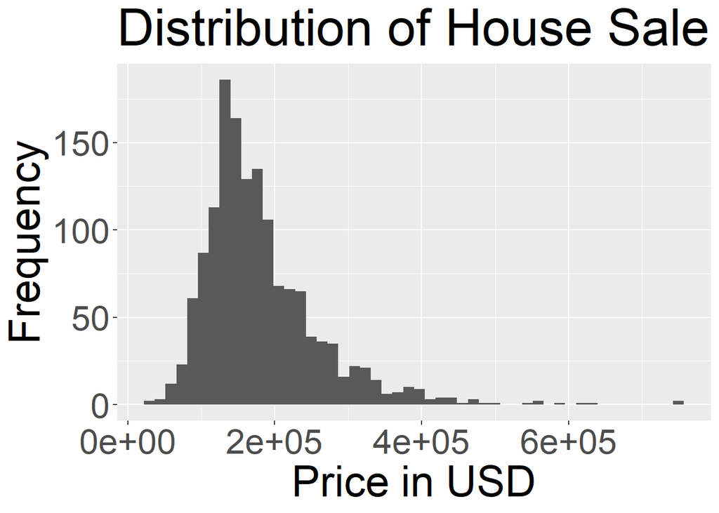

```r
ggplot(data = train, aes(x=SalePrice)) +
geom_histogram(bins = 50) +
labs(title = "Distribution of House Sale Price",
  x = "Price in USD", y = "Frequency")
```

From the histogram, we can clearly see a large right-skew in our distribution with heavy outliers on the upper end. We also see that most houses fall between ~$100K and ~$300K for their sale price.

## 2

## Data Preprocessing and Exploratory Data Analysis

## 2.1 Handling Missing Values

Firstly we need to see which of our variables actually has missing values

```r
missing_cols <- which(colSums(is.na(train))>0)
missing_cols
```

```
##  LotFrontage        Alley   MasVnrType   MasVnrArea     BsmtQual     BsmtCond
##            4            7           26           27           31           32
## BsmtExposure BsmtFinType1 BsmtFinType2   Electrical  FireplaceQu   GarageType
##           33           34           36           43           58           59
##  GarageYrBlt GarageFinish   GarageQual   GarageCond       PoolQC        Fence
##           60           61           64           65           73           74
##  MiscFeature
##           75
```

```r
for(i in missing_cols){
  print(colnames(train[i]))
  print(sum(is.na(train[,i])))
}
```

```
## [1] "LotFrontage"
## [1] 259
## [1] "Alley"
## [1] 1369
## [1] "MasVnrType"
## [1] 8
## [1] "MasVnrArea"
## [1] 8
## [1] "BsmtQual"
## [1] 37
## [1] "BsmtCond"
## [1] 37
## [1] "BsmtExposure"
## [1] 38
## [1] "BsmtFinType1"
```

[output cut: 23 more lines]

From this we can see that we have 19 different variables that have at least one missing value, and we can see the total amount of values that they’re missing. The biggest thing to note from this is that there are some variables, like LotFrontage, which will need to be handled as that variable is one which all houses must have (as all properties have at least some amount of feet that is connected to a street), and therefore they can not just be set to 0 without massively skewing the data. So we will need to use imputation methods for this and other similar columns. However for some columns such as Alley, the missing values aren’t actually indicating that they’re missing from the data, the missing values are indicating that there simply isn’t one. So in cases like Alley we will instead rename the NA into the string “No Alley’’ and then encode it as a categorical variable for Alley and other similar variables. To ensure consistency in our data, for the data points which need to be imputed we will be using the median value of that variable, and group them by the median of a secondary characteristic when applicable. For LotFrontage, we group it by LotShape.

```r
train <- mutate(group_by(train, LotShape), LotFrontage = ifelse(is.na(LotFrontage), median(LotFrontage, na.rm = TRUE), LotFrontage))
sum(is.na(train$LotFrontage))
```

```
## [1] 0
```

Then let’s replace our Alley variable’s missing values

```r
train$Alley <- replace_na(train$Alley, "No Alley")
train
```

```
## # A tibble: 1,460 x 81
## # Groups:   LotShape [4]
##       Id MSSubClass MSZoning LotFrontage LotArea Street Alley    LotShape
##    <int>      <int> <chr>          <dbl>   <int> <chr>  <chr>    <chr>
##  1     1         60 RL                65    8450 Pave   No Alley Reg
##  2     2         20 RL                80    9600 Pave   No Alley Reg
##  3     3         60 RL                68   11250 Pave   No Alley IR1
##  4     4         70 RL                60    9550 Pave   No Alley IR1
##  5     5         60 RL                84   14260 Pave   No Alley IR1
##  6     6         50 RL                85   14115 Pave   No Alley IR1
##  7     7         20 RL                75   10084 Pave   No Alley Reg
##  8     8         60 RL                74   10382 Pave   No Alley IR1
##  9     9         50 RM                51    6120 Pave   No Alley Reg
## 10    10        190 RL                50    7420 Pave   No Alley Reg
## # ... with 1,450 more rows, and 73 more variables: LandContour <chr>,
## #   Utilities <chr>, LotConfig <chr>, LandSlope <chr>, Neighborhood <chr>,
## #   Condition1 <chr>, Condition2 <chr>, BldgType <chr>, HouseStyle <chr>,
## #   OverallQual <int>, OverallCond <int>, YearBuilt <int>, YearRemodAdd <int>,
## #   RoofStyle <chr>, RoofMatl <chr>, Exterior1st <chr>, Exterior2nd <chr>,
## #   MasVnrType <chr>, MasVnrArea <int>, ExterQual <chr>, ExterCond <chr>,
## #   Foundation <chr>, BsmtQual <chr>, BsmtCond <chr>, BsmtExposure <chr>, ...
```

We can now easily see that the data that was missing in Alley has been replaced by our own value.

Knowing what we now know about the data, most null values are categorically equivalent to 0. If a house is missing an alley, they have 0 alleys, and if a house doesn’t have a basement then the basement square footage is 0. Knowing this we can systematically replace parts of other variables in order to align with what we have already done.

```r
for (i in names(train[, missing_cols])) {
  if (str_detect(i, "Bsmt") == TRUE) {
    train[, i][is.na(train[, i])] <- 'No Basement'

  } else if (str_detect(i, "Garage") == TRUE) {
    if (i == 'GarageYrBlt'){
      train[, i][is.na(train[, i])] <- 0
    } else {
      train[, i][is.na(train[, i])] <- 'No Garage'
    }

  }
}

train$MasVnrType <- replace_na(train$MasVnrType, "No Veneer")
train$MasVnrArea <- replace_na(train$MasVnrArea, 0)
train$FireplaceQu <- replace_na(train$FireplaceQu, "No Fireplace")
train$PoolQC <- replace_na(train$PoolQC, "No Pool")
train$Fence <- replace_na(train$Fence, "No Fence")
train$MiscFeature <- replace_na(train$MiscFeature, "No Misc")
```

At this point we have a singular missing value in the Electrical variable. This can be easily replaced without skewing data by either dropping the row, or using the mode of the Electrical variable. For our purposes, we will just be using the mode.

```r
getmode <- function(x){
  uniqx <- unique(x)
  uniqx[which.max(tabulate(match(x, uniqx)))]
}
train <- mutate(train, Electrical = if_else(is.na(Electrical),
                                                    getmode(Electrical),
                                                    Electrical))
sum(is.na(train))
```

```
## [1] 0
```

We have no more missing values in our data set

## 2.2 Exploratory Data Anaylsis

Now that we have a proper grasp of our data set, and have properly filled in all of the missing values in our data, let’s start analyzing features to see what we can take away from the data. Firstly let’s split up the data so that we are able to accurately analyze the continuous/numerical data, and the categorical data.

```r
numericVariables <- names(train)[which(sapply(train, is.numeric))]
categoricalVariables <- names(train)[which(sapply(train, is.character))]
trainingCategorical <- train[which(sapply(train, is.character))]
trainingNumeric <- train[which(sapply(train, is.numeric))]
```

From there we can fairly easily see what the correlation between each numeric variable and the sale price of a home is.

```r
numericCorrelation <- c()
for(i in numericVariables){
  numericCorrelation[i] <- round(cor(trainingNumeric[i], trainingNumeric$SalePrice), 2)
}
numericCorrelation
```

```
##            Id    MSSubClass   LotFrontage       LotArea   OverallQual
##         -0.02         -0.08          0.33          0.26          0.79
##   OverallCond     YearBuilt  YearRemodAdd    MasVnrArea    BsmtFinSF1
##         -0.08          0.52          0.51          0.47          0.39
##    BsmtFinSF2     BsmtUnfSF   TotalBsmtSF     X1stFlrSF     X2ndFlrSF
##         -0.01          0.21          0.61          0.61          0.32
##  LowQualFinSF     GrLivArea  BsmtFullBath  BsmtHalfBath      FullBath
##         -0.03          0.71          0.23         -0.02          0.56
##      HalfBath  BedroomAbvGr  KitchenAbvGr  TotRmsAbvGrd    Fireplaces
##          0.28          0.17         -0.14          0.53          0.47
##   GarageYrBlt    GarageCars    GarageArea    WoodDeckSF   OpenPorchSF
##          0.26          0.64          0.62          0.32          0.32
## EnclosedPorch    X3SsnPorch   ScreenPorch      PoolArea       MiscVal
##         -0.13          0.04          0.11          0.09         -0.02
##        MoSold        YrSold     SalePrice
##          0.05         -0.03          1.00
```

By doing this, each number in numericCorrelation lines up properly with the name of the variable. For our purposes, we’ll be looking specifically through the data that seems to have any noticeable correlation to our sale price:

OveralQual - 0.79

GrLivArea - 0.71

TotalBsmtSF - 0.61

X1stFlrSF - 0.61

GarageCars - 0.64

GarageArea - 0.62

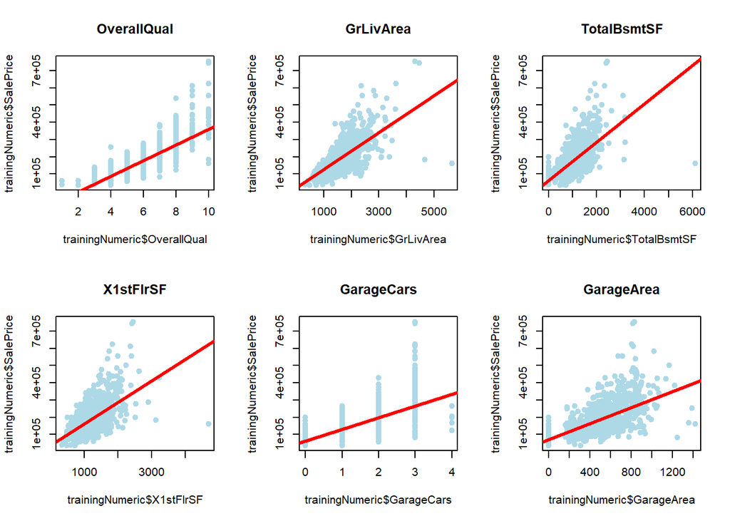

```r
par(mfrow = c(2,3))
# Creating the plot
plot(trainingNumeric$OverallQual, trainingNumeric$SalePrice, pch = 19, col = "lightblue", main = "OverallQual")
# Adding line of best fit
abline(lm(trainingNumeric$SalePrice ~ trainingNumeric$OverallQual), col = "red", lwd = 3)

plot(trainingNumeric$GrLivArea, trainingNumeric$SalePrice, pch = 19, col = "lightblue", main = "GrLivArea")
abline(lm(trainingNumeric$SalePrice ~ trainingNumeric$GrLivArea), col = "red", lwd = 3)

plot(trainingNumeric$TotalBsmtSF, trainingNumeric$SalePrice, pch = 19, col = "lightblue", main = "TotalBsmtSF")
abline(lm(trainingNumeric$SalePrice ~ trainingNumeric$TotalBsmtSF), col = "red", lwd = 3)

plot(trainingNumeric$X1stFlrSF, trainingNumeric$SalePrice, pch = 19, col = "lightblue", main = "X1stFlrSF")
abline(lm(trainingNumeric$SalePrice ~ trainingNumeric$X1stFlrSF), col = "red", lwd = 3)

plot(trainingNumeric$GarageCars, trainingNumeric$SalePrice, pch = 19, col = "lightblue", main = "GarageCars")
abline(lm(trainingNumeric$SalePrice ~ trainingNumeric$GarageCars), col = "red", lwd = 3)

plot(trainingNumeric$GarageArea, trainingNumeric$SalePrice, pch = 19, col = "lightblue", main = "GarageArea")
abline(lm(trainingNumeric$SalePrice ~ trainingNumeric$GarageArea), col = "red", lwd = 3)
```

We can then plot all of these correlation graphs, along with their regression line to get a better look at their correlation between them and sale price. We could do the same for every one of our numeric variables, but when we deal with correlation coefficients that are less than 0.6, we’re stretching too far on their actual correlation. All of our variables are on the X axis, with Sale Price being on the Y axis.

Neighborhood

LotShape

Condition1

HouseStyle

Exterior1st

Exterior2nd

MasVnrType

ExterQual

Foundation

BsmtQual

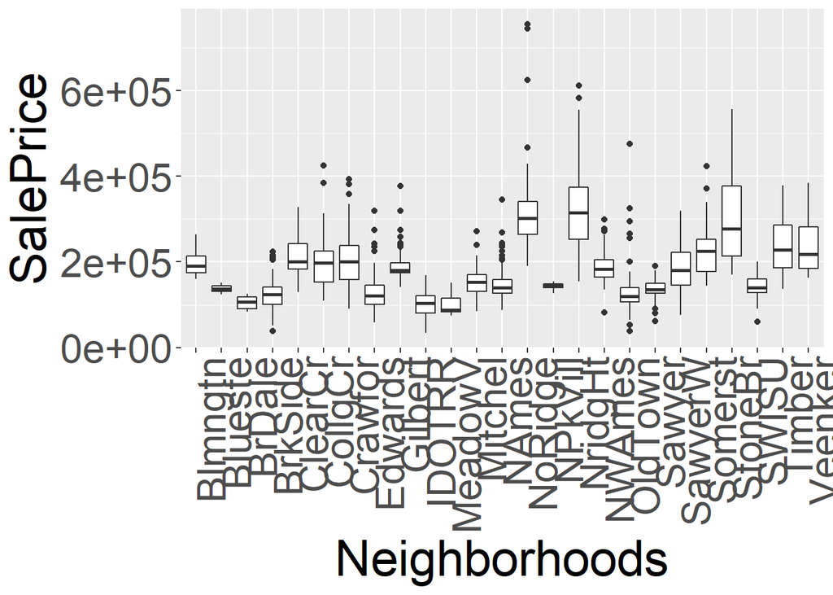

```r
train %>% select(Neighborhood, SalePrice) %>% ggplot(aes(factor(Neighborhood), SalePrice)) + geom_boxplot() + theme(axis.text.x = element_text(angle = 90, hjust =1)) + xlab('Neighborhoods')
```

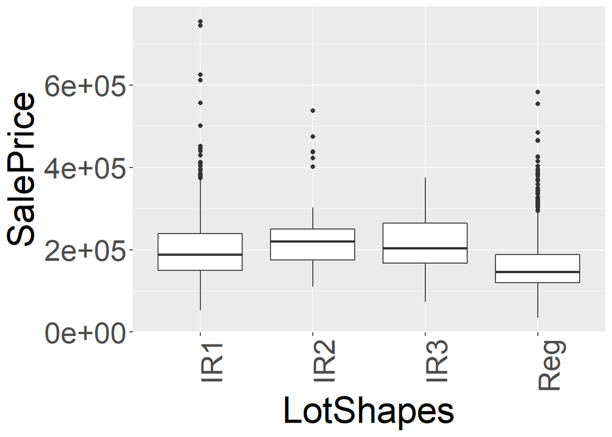

```r
train %>% select(LotShape, SalePrice) %>% ggplot(aes(factor(LotShape), SalePrice)) + geom_boxplot() + theme(axis.text.x = element_text(angle = 90, hjust =1)) + xlab('LotShapes')
```

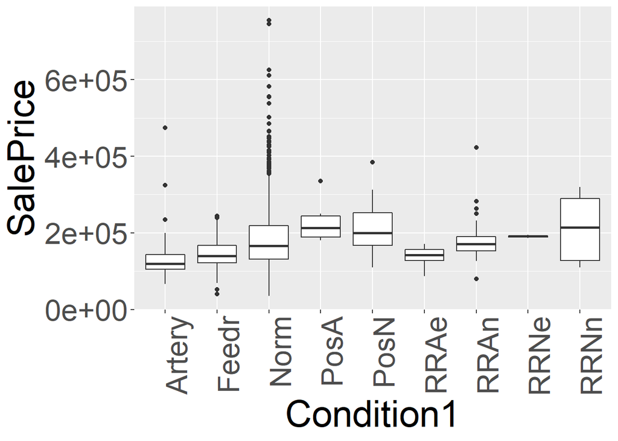

```r
train %>% select(Condition1, SalePrice) %>% ggplot(aes(factor(Condition1), SalePrice)) + geom_boxplot() + theme(axis.text.x = element_text(angle = 90, hjust =1)) + xlab('Condition1')
```

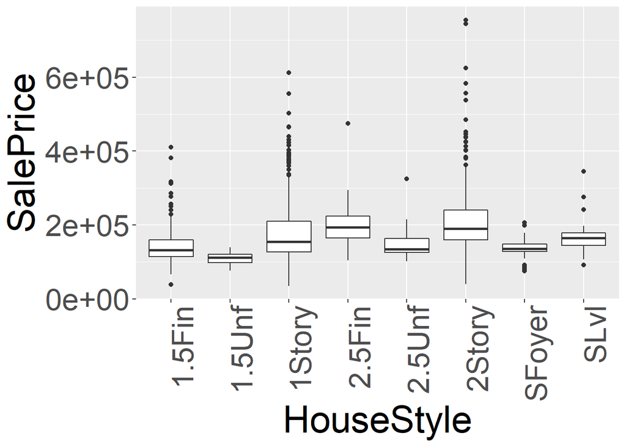

```r
train %>% select(HouseStyle, SalePrice) %>% ggplot(aes(factor(HouseStyle), SalePrice)) + geom_boxplot() + theme(axis.text.x = element_text(angle = 90, hjust =1)) + xlab('HouseStyle')
```

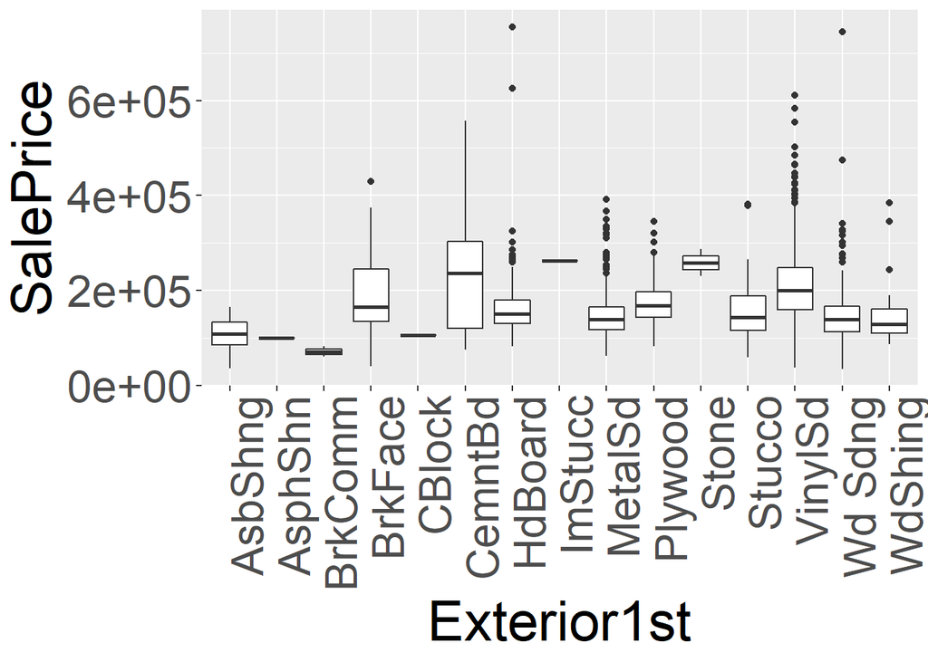

```r
train %>% select(Exterior1st, SalePrice) %>% ggplot(aes(factor(Exterior1st), SalePrice)) + geom_boxplot() + theme(axis.text.x = element_text(angle = 90, hjust =1)) + xlab('Exterior1st')
```

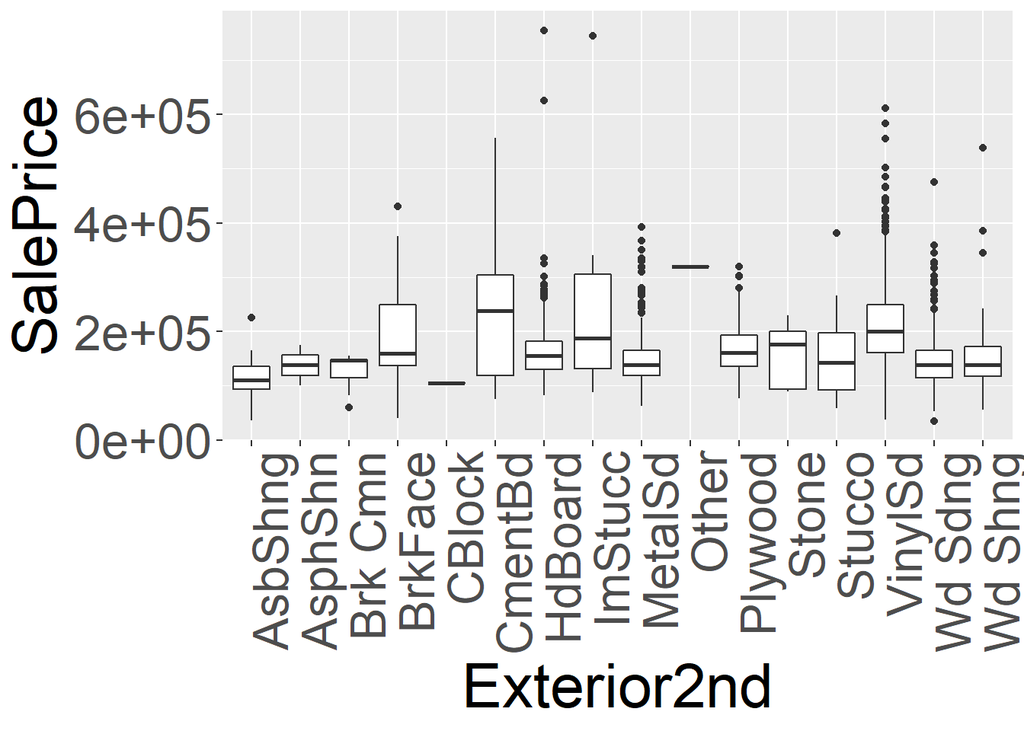

```r
train %>% select(Exterior2nd, SalePrice) %>% ggplot(aes(factor(Exterior2nd), SalePrice)) + geom_boxplot() + theme(axis.text.x = element_text(angle = 90, hjust =1)) + xlab('Exterior2nd')
```

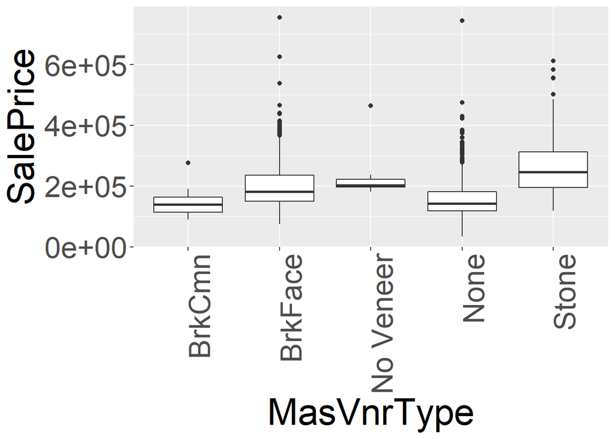

```r
train %>% select(MasVnrType, SalePrice) %>% ggplot(aes(factor(MasVnrType), SalePrice)) + geom_boxplot() + theme(axis.text.x = element_text(angle = 90, hjust =1)) + xlab('MasVnrType')
```

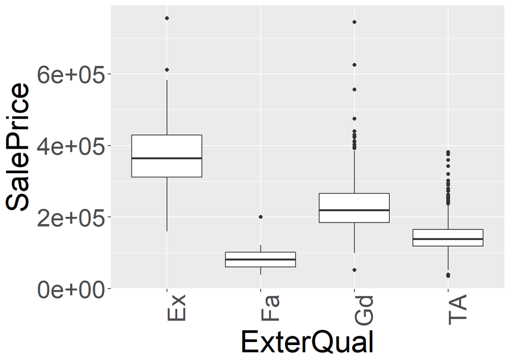

```r
train %>% select(ExterQual, SalePrice) %>% ggplot(aes(factor(ExterQual), SalePrice)) + geom_boxplot() + theme(axis.text.x = element_text(angle = 90, hjust =1)) + xlab('ExterQual')
```

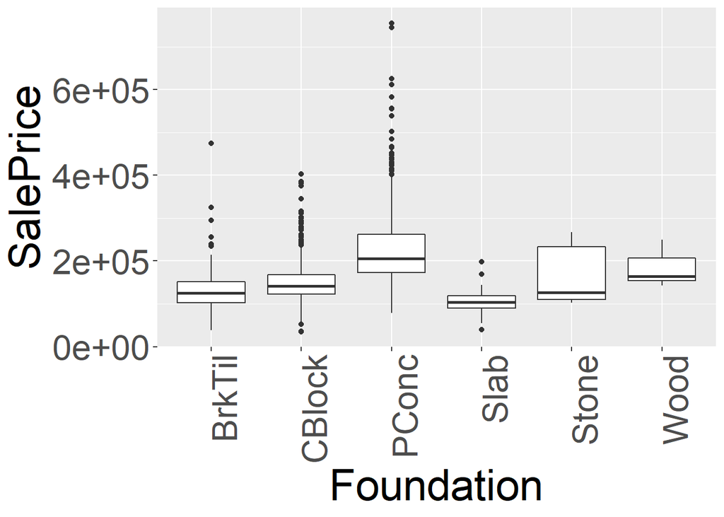

```r
train %>% select(Foundation, SalePrice) %>% ggplot(aes(factor(Foundation), SalePrice)) + geom_boxplot() + theme(axis.text.x = element_text(angle = 90, hjust =1)) + xlab('Foundation')
```

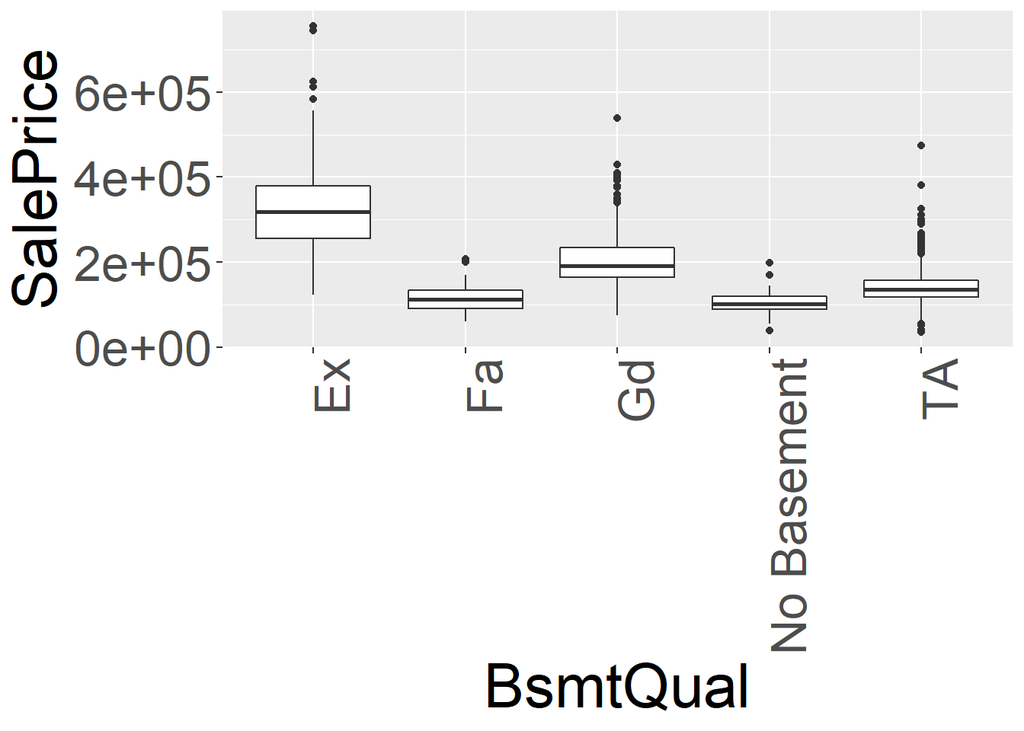

```r
train %>% select(BsmtQual, SalePrice) %>% ggplot(aes(factor(BsmtQual), SalePrice)) + geom_boxplot() + theme(axis.text.x = element_text(angle = 90, hjust =1)) + xlab('BsmtQual')
```

Finally, let’s explore the correlation between our numeric variables, so that we’re able to have a proper grasp on which ones can have an effect on the others.

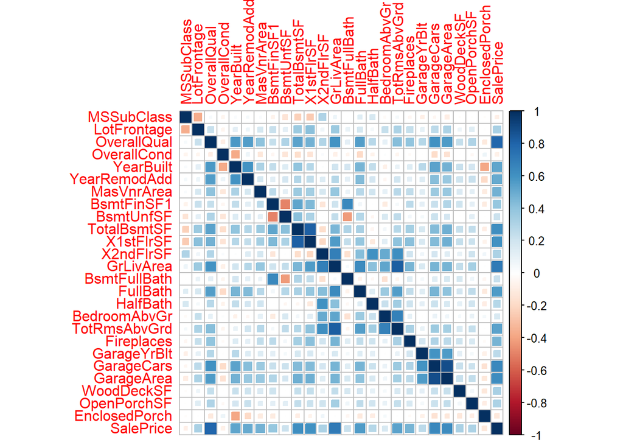

```r
correlations <- cor(trainingNumeric)

# correlations
row_indic <- apply(correlations, 1, function(x) sum(x > 0.3 | x < -0.3) > 1)

correlations<- correlations[row_indic ,row_indic ]
corrplot(correlations, method="square")
```

## Acknowledgements

Kaggle Competition Data: https://www.kaggle.com/competitions/house-prices-advanced-regression-techniques

General Guide for Missing Data and code: Akoua Orsot - https://www.kaggle.com/code/akouaorsot/house-price-prediction#3.-Data-Cleaning

General Guide for Exploratory Data Analysis and code: Min02Yam - https://www.kaggle.com/code/min02yam/detailed-exploratory-data-analysis-using-r